# Challenge B

Maxime GRANDMAITRE Gauderic THIETART Margaux SINCEUX

06/12/2017

### TASK 1B : Predicting house prices in Ames, Iowa

We clean our training database as we did in Challenge A : - we omit the NA - we convert all character variables into factors

## Question 1: choose a ML technique

Random Forest is a Machine Learning algorithm wich is efficient to spot the links between one independent variable and some explanatory ones. Random Forest will classify the explanatory variables in function of their links with the variable we have to explain. It consists of doing the predictions average of multiple independent models to reduce the variance and so the prediction error.

```r
library(randomForest)
```

## Question 2: Train the chosen technique on the training data

We use the random forest method by doing a regression, and deleting the “Id”.

```r
set.seed(123)
fit <- randomForest(SalePrice~.-Id, data = train)
print(fit)
```

```
##
## Call:
##  randomForest(formula = SalePrice ~ . - Id, data = train)
##                Type of random forest: regression
##                      Number of trees: 500
## No. of variables tried at each split: 24
##
##           Mean of squared residuals: 792923183
##                     % Var explained: 87.26
```

We are doing varImpPlot to analyze which variables have more impact on the Sale Price.

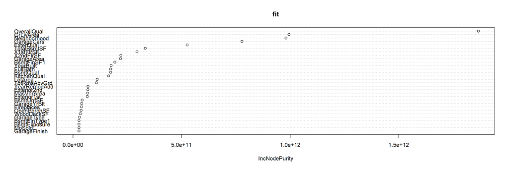

```r
varImpPlot(fit)
```

It is the same thing but in a table format.

```r
fit$importance[order(fit$importance[, 1], decreasing = TRUE), ]
```

```
##   OverallQual     GrLivArea  Neighborhood    GarageCars     ExterQual
##  1.867376e+12  9.947095e+11  9.804184e+11  7.781664e+11  5.258180e+11
##   TotalBsmtSF     X1stFlrSF     X2ndFlrSF    GarageArea    BsmtFinSF1
##  3.332303e+11  2.944926e+11  2.206979e+11  2.192564e+11  1.930225e+11
##     YearBuilt      FullBath      BsmtQual   KitchenQual       LotArea
##  1.759303e+11  1.733255e+11  1.729592e+11  1.645110e+11  1.116813e+11
##  TotRmsAbvGrd  YearRemodAdd   Exterior2nd    MasVnrArea   Exterior1st
##  1.079355e+11  6.927770e+10  6.823789e+10  6.712568e+10  6.596879e+10
##     BsmtUnfSF   GarageYrBlt    Fireplaces   OpenPorchSF    WoodDeckSF
##  4.190521e+10  3.988652e+10  3.900062e+10  3.706281e+10  3.403791e+10
##    GarageType  BsmtFinType1  BsmtExposure        MoSold  GarageFinish
##  3.032681e+10  2.771064e+10  2.766030e+10  2.747499e+10  2.735182e+10
##   OverallCond      MSZoning  BedroomAbvGr    HouseStyle    MSSubClass
##  2.451285e+10  1.941212e+10  1.902986e+10  1.714502e+10  1.664387e+10
## SaleCondition   LandContour  BsmtFullBath     LotConfig        YrSold
##  1.544624e+10  1.474222e+10  1.359481e+10  1.288784e+10  1.243108e+10
##      LotShape     RoofStyle    MasVnrType      HalfBath    Condition1
##  1.151920e+10  1.126130e+10  1.107057e+10  9.932382e+09  9.598063e+09
##   ScreenPorch    Foundation      SaleType     HeatingQC    Functional
##  9.253386e+09  9.039261e+09  8.946245e+09  8.555804e+09  6.498640e+09
##    CentralAir      PoolArea     LandSlope EnclosedPorch      RoofMatl
##  6.424842e+09  6.094925e+09  5.951381e+09  5.878999e+09  5.142328e+09
##      BldgType  BsmtFinType2     ExterCond    BsmtFinSF2    GarageQual
##  5.097134e+09  4.528857e+09  4.459573e+09  4.451311e+09  3.763106e+09
##      BsmtCond  BsmtHalfBath  KitchenAbvGr    PavedDrive    Condition2
##  3.723160e+09  3.464209e+09  2.973711e+09  2.005044e+09  1.923166e+09
##    Electrical    GarageCond    X3SsnPorch  LowQualFinSF       Heating
##  1.844362e+09  1.555179e+09  1.537852e+09  1.301425e+09  1.043248e+09
##       MiscVal        Street     Utilities
##  8.762859e+08  1.363551e+08  8.634947e+06
```

## Question 3: Make predictions on the test data, and compare them to the predictions of a linear regression of your choice

We had to transform the factor variables because they have not the same levels in the data train and the data test. So we modified this to have the same levels.

```r
levels(test$Utilities) <- levels(train$Utilities)
levels(test$Condition2) <- levels(train$Condition2)
levels(test$HouseStyle) <- levels(train$HouseStyle)
levels(test$RoofMatl) <- levels(train$RoofMatl)
levels(test$Exterior2nd) <- levels(train$Exterior2nd)
levels(test$Electrical) <- levels(train$Electrical)
levels(test$GarageQual) <- levels(train$GarageQual)
levels(test$Exterior1st) <- levels(train$Exterior1st)
levels(test$Heating) <- levels(train$Heating)


prediction <- data.frame(Id= test$Id, SalePrice_predict = predict(fit, test, type="response"))
```

We took the linear regression of challenge A to compare it with our new predicitons.

```r
library(ggplot2)

predict2 <- data.frame(prediction, prediction_lm)
pred <- predict2[,-3]

plot <- ggplot(pred, aes (x = Id, y = SalePrice_predict)) +
  geom_point(data = prediction, aes(color="prediction")) +
  geom_point(data = prediction_lm, aes(color="prediction_lm"))

difference <- prediction_lm - prediction
summary(abs(difference[,2]))
```

```
##      Min.   1st Qu.    Median      Mean   3rd Qu.      Max.
##     13.99   7758.65  17260.04  22369.78  30767.40 112947.02
```

### Task 2B : Overfitting in Machine Learning

```r
rm(list = ls())

library(tidyverse)
library(np)
library(caret)
# True model : y = x^3 + epsilon
set.seed(1)
Nsim <- 150
b <- c(0,1)
x0 <- rep(1, Nsim)
x1 <- rnorm(n = Nsim)

X <- cbind(x0, x1^3)
y.true <- X %*% b

eps <- rnorm(n = Nsim)
y <- X %*% b + eps

df <- tbl_df(y[,1]) %>% rename(y = value) %>% bind_cols(tbl_df(x1)) %>% rename(x = value) %>% bind_cols(tbl_df(y.true[,1])) %>% rename(y.true = value)
```

We split sample into training and testing

```r
training.index <- createDataPartition(y = y, times = 1, p = 0.8)
df <- df %>% mutate(which.data = ifelse(1:n() %in% training.index$Resample1, "training", "test"))

training <- df %>% filter(which.data == "training")
test <- df %>% filter(which.data == "test")
```

We do a linear regression

```r
lm.fit <- lm(y ~ x, data = training)
summary(lm.fit)
```

```
##
## Call:
## lm(formula = y ~ x, data = training)
##
## Residuals:
##     Min      1Q  Median      3Q     Max
## -4.7575 -1.0695  0.0419  1.0229  7.6216
##
## Coefficients:
##             Estimate Std. Error t value Pr(>|t|)
## (Intercept)   0.1950     0.1649   1.183    0.239
## x             2.4446     0.1846  13.241   <2e-16 ***
## ---
## Signif. codes:  0 '***' 0.001 '**' 0.01 '*' 0.05 '.' 0.1 ' ' 1
##
## Residual standard error: 1.82 on 120 degrees of freedom
## Multiple R-squared:  0.5937, Adjusted R-squared:  0.5903
## F-statistic: 175.3 on 1 and 120 DF,  p-value: < 2.2e-16
```

```r
df <- df %>% mutate(y.lm = predict(object = lm.fit, newdata = df))
training <- training %>% mutate(y.lm = predict(object = lm.fit))
```

## Step 1 : lowflex

```r
ll.fit.lowflex <- npreg(y ~ x, data = training, method = "ll", bws = 0.5)
summary(ll.fit.lowflex)
```

```
##
## Regression Data: 122 training points, in 1 variable(s)
##                 x
## Bandwidth(s): 0.5
##
## Kernel Regression Estimator: Local-Constant
## Bandwidth Type: Fixed
## Residual standard error: 1.442574
## R-squared: 0.8569977
##
## Continuous Kernel Type: Second-Order Gaussian
## No. Continuous Explanatory Vars.: 1
```

## Step 2 : highflex

```r
ll.fit.highflex <- npreg(y ~ x, data = training, method = "ll", bws = 0.01)
summary(ll.fit.highflex)
```

```
##
## Regression Data: 122 training points, in 1 variable(s)
##                  x
## Bandwidth(s): 0.01
##
## Kernel Regression Estimator: Local-Constant
## Bandwidth Type: Fixed
## Residual standard error: 0.5882872
## R-squared: 0.9569811
##
## Continuous Kernel Type: Second-Order Gaussian
## No. Continuous Explanatory Vars.: 1
```

### step 3 : plot highflex and lowflex in the training data

```r
df <- df %>% mutate(y.ll.lowflex = predict(object = ll.fit.lowflex, newdata = df), y.ll.highflex = predict(object = ll.fit.highflex, newdata = df))


training <- training %>% mutate(y.ll.lowflex = predict(object = ll.fit.lowflex, newdata = training), y.ll.highflex = predict(object = ll.fit.highflex, newdata = training))

training
```

```
## # A tibble: 122 x 7
##              y          x       y.true which.data       y.lm y.ll.lowflex
##          <dbl>      <dbl>        <dbl>      <chr>      <dbl>        <dbl>
##  1  0.20433883 -0.6264538 -0.245848275   training -1.3363726 -0.200217871
##  2 -0.01236649  0.1836433  0.006193347   training  0.6439806  0.182352673
##  3  3.13050121  1.5952808  4.059863355   training  4.0948517  3.023714572
##  4 -1.45168388  0.3295078  0.035776429   training  1.0005590  0.236226060
##  5 -1.62750566 -0.8204684 -0.552313364   training -1.8106582 -0.425804071
##  6  1.11583565  0.4874291  0.115806846   training  1.3866113  0.310101940
##  7 -0.21878864  0.7383247  0.402478052   training  1.9999477  0.498338173
##  8 -1.19354142  0.5757814  0.190885432   training  1.6025962  0.363540869
##  9  1.84080947 -0.3053884 -0.028481152   training -0.5515002  0.007813978
## 10 -0.17939960  0.3898432  0.059247498   training  1.1480543  0.261909431
## # ... with 112 more rows, and 1 more variables: y.ll.highflex <dbl>
```

```r
test <- test %>% mutate(y.ll.lowflex = predict(object = ll.fit.lowflex, newdata = test), y.ll.highflex = predict(object = ll.fit.highflex, newdata = test))

test
```

```
## # A tibble: 28 x 6
##             y          x       y.true which.data y.ll.lowflex
##         <dbl>      <dbl>        <dbl>      <chr>        <dbl>
##  1 -0.9015671 -0.8356286 -0.583498718       test  -0.44815580
##  2  3.8802495  1.5117812  3.455149104       test   2.60289580
##  3  0.8187215 -0.6212406 -0.239761502       test  -0.19548025
##  4 -0.5837001  0.9438362  0.840794584       test   0.77420576
##  5  0.4094355  0.8212212  0.553835065       test   0.59241185
##  6  0.9008803  1.1000254  1.331092102       test   1.09962838
##  7  0.6575602  1.4330237  2.942795753       test   2.23958632
##  8  0.5076451 -0.1350546 -0.002463362       test   0.07595184
##  9 10.2105426  2.1726117 10.255251705       test   6.57995968
## 10 -1.6257013  0.4755095  0.107517132       test   0.30368108
## # ... with 18 more rows, and 1 more variables: y.ll.highflex <dbl>
```

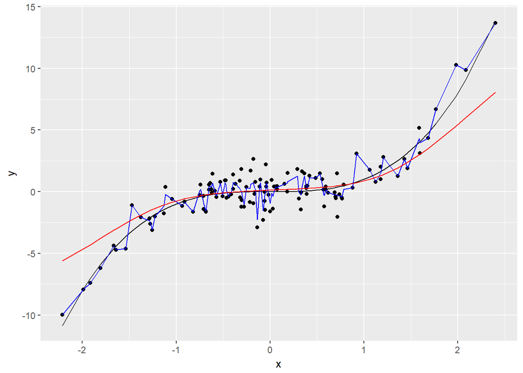

```r
ggplot(training) + geom_point(mapping = aes(x = x, y = y)) +
  geom_line(mapping = aes(x = x, y = y.true)) +
  geom_line(mapping = aes(x = x, y = y.ll.highflex), col="blue") +
  geom_line(mapping = aes(x = x, y = y.ll.lowflex), col="red")
```

## Step 4 : analysis

According to the plot, we can conclude that the predictions from ll.fit.highflex are more variable than the ones from ll.fit.lowflex but he has also least bias.

## Step 5 : plot highflex and lowflex in the test data

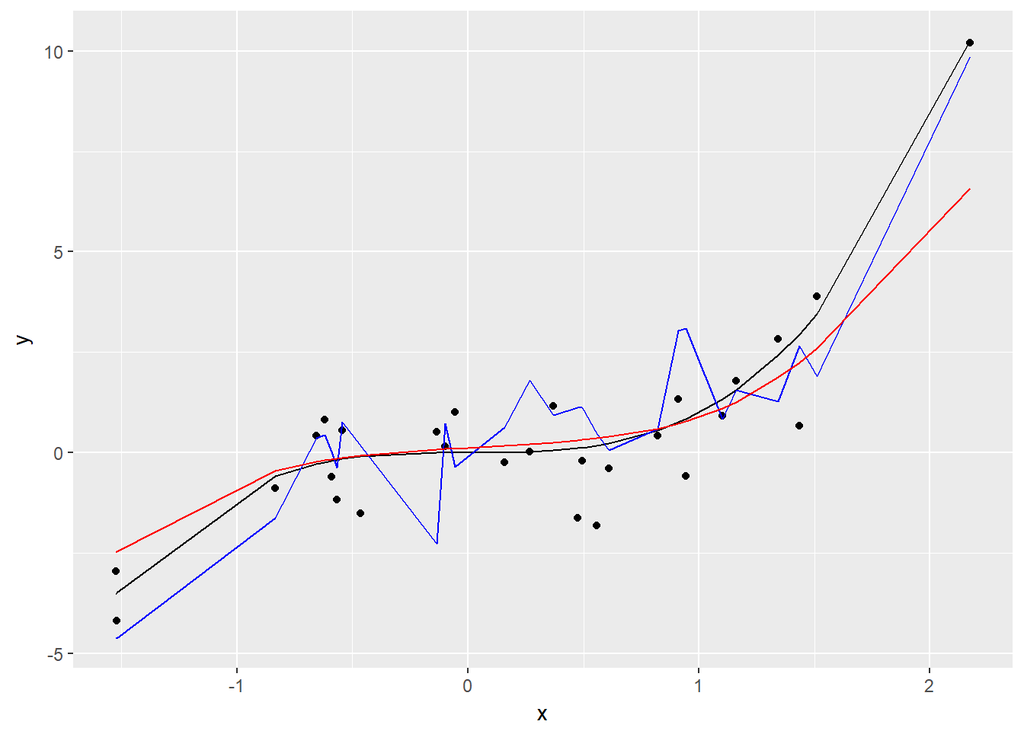

```r
ggplot(test) + geom_point(mapping = aes(x = x, y = y)) +
  geom_line(mapping = aes(x = x, y = y.true)) +
  geom_line(mapping = aes(x = x, y = y.ll.highflex), col="blue") +
  geom_line(mapping = aes(x = x, y = y.ll.lowflex), col="red")
```

We can see graphicaly than the predictions from ll.fit.highflex are more variable than the ones from ll.fit.lowflex when we are on the limit of the graph, but he has also least bias.

## Step 6 : Create vector of several bandwidth

```r
bw <- seq(0.01, 0.5, by = 0.001)
```

```r
llbw.fit <- lapply(X = bw, FUN = function(bw) {npreg(y ~ x, data = training, method = "ll", bws = bw)})
head (llbw.fit)
```

```
## [[1]]
##
## Regression Data: 122 training points, in 1 variable(s)
##                  x
## Bandwidth(s): 0.01
##
## Kernel Regression Estimator: Local-Constant
## Bandwidth Type: Fixed
##
## Continuous Kernel Type: Second-Order Gaussian
## No. Continuous Explanatory Vars.: 1
##
##
## [[2]]
##
## Regression Data: 122 training points, in 1 variable(s)
##                   x
## Bandwidth(s): 0.011
##
## Kernel Regression Estimator: Local-Constant
## Bandwidth Type: Fixed
##
## Continuous Kernel Type: Second-Order Gaussian
## No. Continuous Explanatory Vars.: 1
##
##
## [[3]]
##
## Regression Data: 122 training points, in 1 variable(s)
##                   x
## Bandwidth(s): 0.012
##
## Kernel Regression Estimator: Local-Constant
## Bandwidth Type: Fixed
##
## Continuous Kernel Type: Second-Order Gaussian
## No. Continuous Explanatory Vars.: 1
##
##
## [[4]]
```

[output cut: 21 more lines]

```
## Continuous Kernel Type: Second-Order Gaussian
## No. Continuous Explanatory Vars.: 1
##
##
## [[6]]
##
## Regression Data: 122 training points, in 1 variable(s)
##                   x
## Bandwidth(s): 0.015
##
## Kernel Regression Estimator: Local-Constant
## Bandwidth Type: Fixed
##
## Continuous Kernel Type: Second-Order Gaussian
## No. Continuous Explanatory Vars.: 1
```

## Step 8 : Compute for each bandwidth the MSE-training

```r
mse.training <- function(fit.model){
  predictions <- predict(object = fit.model, newdata = training)
  training %>% mutate(squared.error = (y - predictions)^2) %>% summarize(mse = mean(squared.error))
}
mse.train.results <- unlist(lapply(X = llbw.fit, FUN = mse.training))
head (mse.train.results)
```

```
##       mse       mse       mse       mse       mse       mse
## 0.3460818 0.3708529 0.3947976 0.4181274 0.4408973 0.4630605
```

## Step 9: Compute for each bandwidth the MSE-test

```r
mse.test <- function(fit.model){
  predictions <- predict(object = fit.model, newdata = test)
  test %>% mutate(squared.error = (y - predictions)^2) %>% summarize(mse = mean(squared.error))
}
mse.test.results <- unlist(lapply(X = llbw.fit, FUN = mse.test))
head (mse.test.results)
```

```
##      mse      mse      mse      mse      mse      mse
## 2.257278 2.189654 2.126863 2.071231 2.023309 1.982573
```

## Step 10 : Plot

```
## # A tibble: 491 x 3
##    bandwidth mse.train mse.test
##        <dbl>     <dbl>    <dbl>
##  1     0.010 0.3460818 2.257278
##  2     0.011 0.3708529 2.189654
##  3     0.012 0.3947976 2.126863
##  4     0.013 0.4181274 2.071231
##  5     0.014 0.4408973 2.023309
##  6     0.015 0.4630605 1.982573
##  7     0.016 0.4845110 1.947912
##  8     0.017 0.5051165 1.917947
##  9     0.018 0.5247438 1.891276
## 10     0.019 0.5432788 1.866645
## # ... with 481 more rows
```

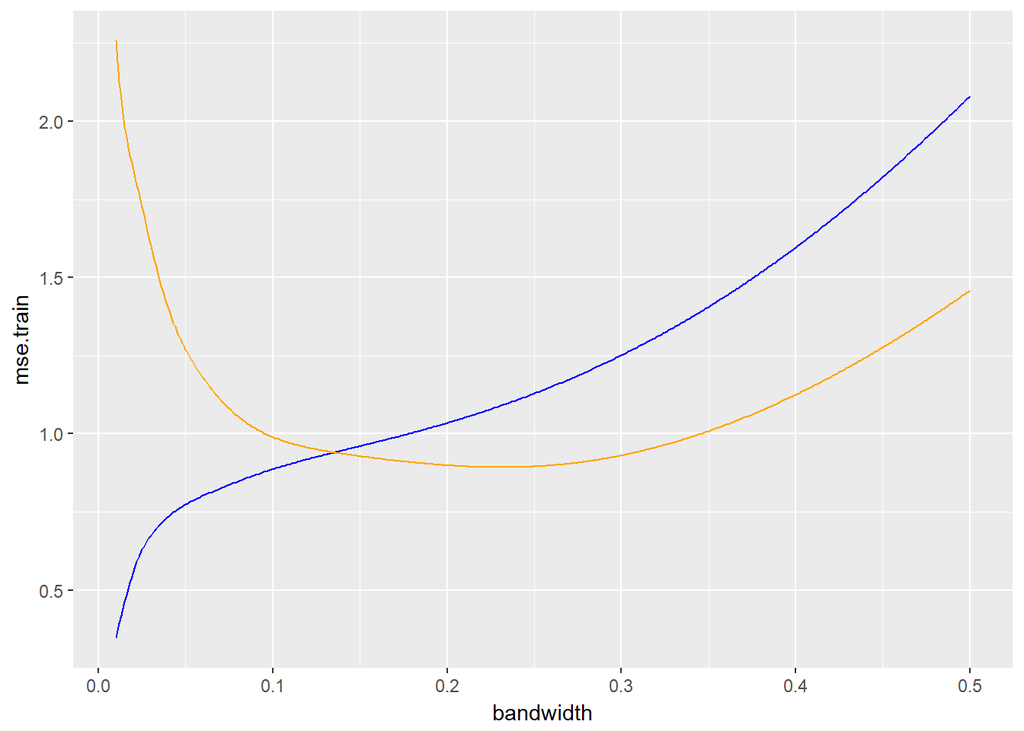

```r
ggplot(mse.df) +
  geom_line(mapping = aes(x = bandwidth, y = mse.train), color = "blue") +
  geom_line(mapping = aes(x = bandwidth, y = mse.test), color = "orange")
```

### Task 3B : Privacy regulation compliance in France

## Step 1 : Import Data

```r
library(data.table)
mat <- fread(file.choose("~/master 1 S1/r/challenge B/sirene_201710_L_M/sirc-17804_9075_14209_201710_L_M_20171101_030132835.csv"),sep =";", dec = ".", header = T, select = c("SIREN", "LIBTEFEN", "DATEMAJ"))
```

[output not shown]

[output cut: 112 more lines]

[output not shown]

```r
head (mat)
```

```
##        SIREN         LIBTEFEN             DATEMAJ
## 1: 000325175        0 salarié 2014-01-08T00:00:00
## 2: 005420021 10 à 19 salariés 2011-07-19T00:00:00
## 3: 005420120 10 à 19 salariés 1997-09-02T00:00:00
## 4: 005420120 10 à 19 salariés 2014-08-28T00:00:00
## 5: 005420120 10 à 19 salariés 2017-03-03T00:00:00
## 6: 005420120 10 à 19 salariés 2010-12-24T00:00:00
```

## Step 2 : Nice table

```r
cil <- read.csv(file.choose("OpenCNIL_Organismes_avec_CIL_VD_20171204"),header = T, dec = ".",sep = ";")
attach(cil)
```

We change the “code postal” by taking the first two digits.

```r
departement <- substr (cil$Code_Postal, 1,2)
departement = as.factor(departement)
dep_clear <- data.frame(summary(departement))
dep_clear
```

```
##         summary.departement.
## 75                      2114
## 92                       943
## 69                       601
## 59                       550
## 13                       471
## 38                       422
## 33                       371
## 44                       342
## 31                       318
## 53                       316
## 93                       313
## 76                       299
## 94                       293
## 34                       292
```

[output cut: 86 more lines]

## Step 3 : SIREN - CNIL

We start by rename the variable Ã¯..siren by SIREN for obtained the same name of the variable siren between matrice and cil.

After that we merge the SIREN dataset into the CNIL data with the merge function.

[output not shown]

## Step 4 : histogram

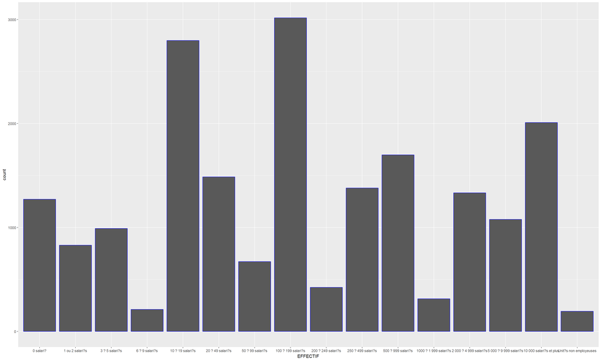

```r
clean <- last[order(last$LIBTEFEN, decreasing=TRUE),]

clean$EFFECTIF <- factor(clean$LIBTEFEN, labels= c("0 salari?", "1 ou 2 salari?s", "3 ? 5 salari?s", "6 ? 9 salari?s", "10 ? 19 salari?s", "20 ? 49 salari?s", "50 ? 99 salari?s", "100 ? 199 salari?s", "200 ? 249 salari?s", "250 ? 499 salari?s", "500 ? 999 salari?s", "1000 ? 1 999 salari?s", "2 000 ? 4 999 salari?s", "5 000 ? 9 999 salari?s", "10 000 salari?s et plus", "Unit?s non employeuses"))


library(ggplot2)
ggplot(clean, aes(EFFECTIF)) +
  geom_histogram(stat="count", col="blue")
```